# academic_engagement

Kevin Gilds, MPA

June 13, 2016

# Academic Engagement

Academic Engagement questions gauge tangible behaviors that help students succeed in school. Questions that measure Academic Engagement include the following.

**Acadeimc Engagement Questions**

1. I talk with my teachers before or after school, or during lunch about my assignments.
2. I hand in my assignments on time
3. I finish my homework even if it is boring
4. If I can’t understand my schoolwork at first, I keep trying until I do understand it.

The number of pre and post survey that could be matched is **74**,and the percent of students with a successful outcome is **63.51%**

1. The number of students achieving the academic engagement outcome at a high level is **31**
2. The number of students who did not achieve outcome at high level but increased their outcome score is **16**

The improvement in outcome scores is graphically represented below.

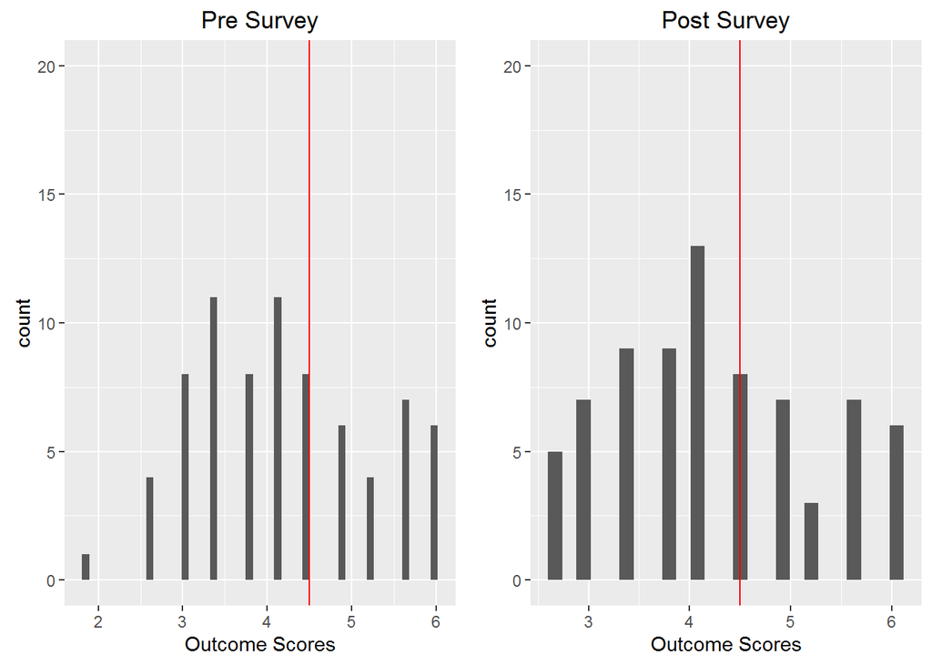

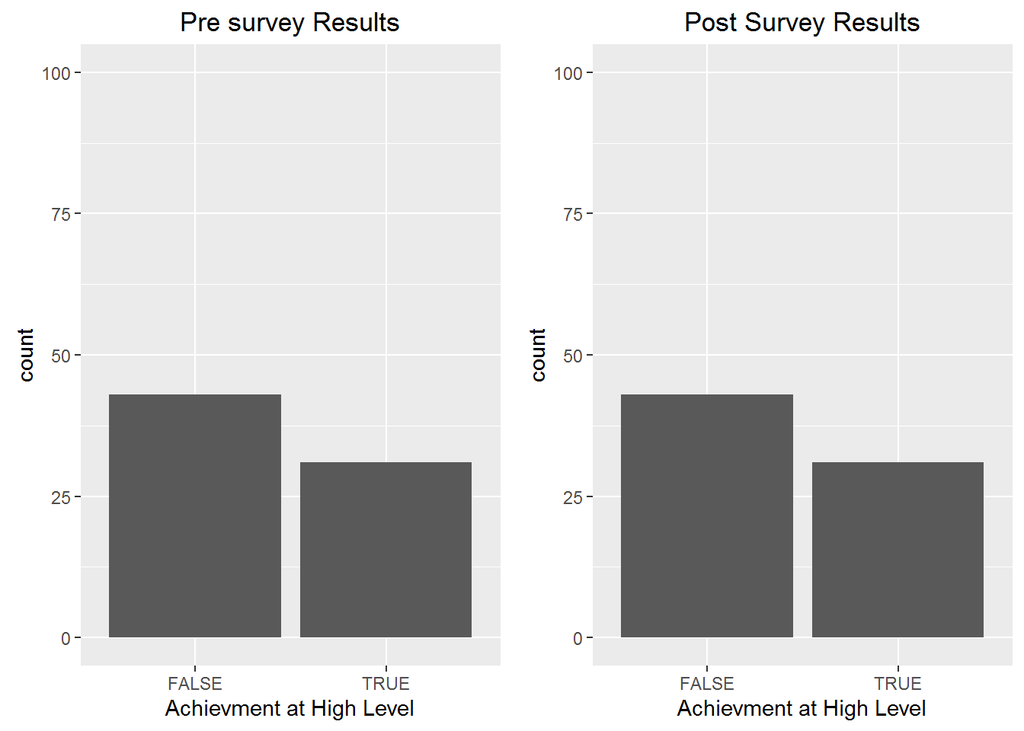

The percent of students who went from low achievement to high achievement is **14.86%** The number of students who had the opportunity to improve their academic engagement outcome score is **65**, and their mean increase in outcome score is **-0.0115385**

The increase in the academic engagement outcome scores is represented graphically below. Marks to the right of the vertical red line represents an increase in the outcome score. Marks above the horizontal line represents scores above the high and low achievement.

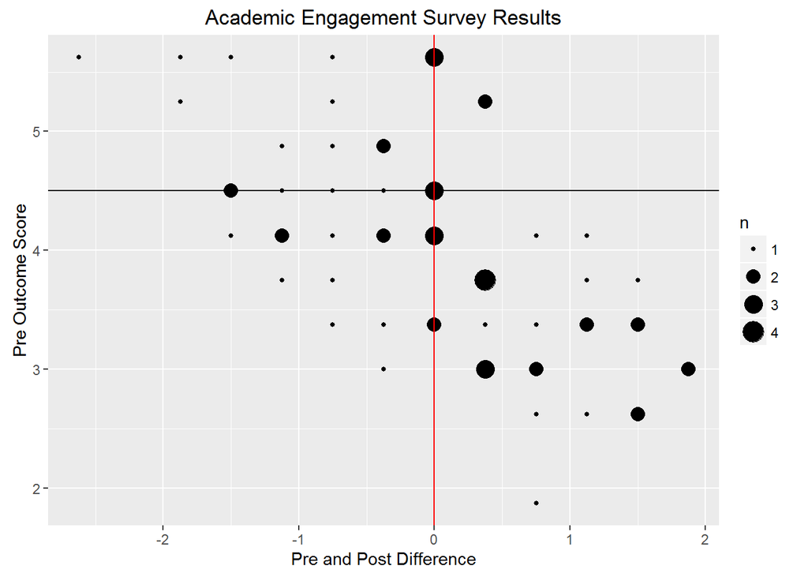

Two statistical tests were administered on the matched survey results the Wilcox test and Cohen’s D test.

The outcome distributions did not approximate a normal distribution, thus A Wilcox.test was administered and the results show that the difference between the pre and post outcome scores are not significant at .05 level.

Wilcoxon signed rank test with continuity correction: `ae_2016$Pre` and `ae_2016$Post`

| Test statistic | P value | Alternative hypothesis |
| --- | --- | --- |
| 872 | 0.3764 | less |

```
##
## Cohen's d
##
## d estimate: -0.03529573 (negligible)
## 95 percent confidence interval:
##        inf        sup
## -0.3624486  0.2918572
```